# Linking_questions_final

## Linking questions/Bridging the datasets

## Setup

Load the tidyverse for the data preparation and plots used in this section.

# Question 1

## Using their unique donor IDs, how many patients appear across all four arms of the study?

To work out how many patients appear across the datasets, we need to match them using donorid. We can first use select() and distinct() to keep one row per donor in each dataframe. Since these dataframes already use the same donorid column, we do not need to rename it. We can also use mutate() to add a column showing which dataset each donor appears in. This will help us check the matches after joining them together.

`clb load("../data/prs.Rda") load("../data/gait.Rda") load("../data/rnaseq.Rda") load("../data/rnaseq_gene_info.Rda") load("../data/drugscreen.Rda") genetics_donors <- ca_co_genotypes %>% select(donorid) %>% distinct() %>% mutate(in_genetics = TRUE) rnaseq_donors <- dge$samples %>% select(donorid) %>% distinct() %>% mutate(in_rnaseq = TRUE) gait_donors <- gait_data %>% select(donorid) %>% distinct() %>% mutate(in_gait = TRUE)}`

Now that the dataframes have the same donorid column, we can use left_join() to add the RNA-seq and clinical trial information to genetics_donors. This works in the same way as joining the genotype and GWAS data in the population genetics analysis. However, left_join() keeps all donors from the first dataframe, including those without a match. For donors who do not appear in RNA-seq or the clinical trial, the corresponding new column will contain NA.

`clb donor_data <- genetics_donors %>% left_join(rnaseq_donors, by = "donorid") %>% left_join(gait_donors, by = "donorid") head(donor_data)}`

Looking at donor_data, each donor now has columns showing which datasets they appear in. We only want the patients who appear in all three, so we can use filter() to keep the rows where all three columns are TRUE. As such, the unmatched donors are removed before we count the remaining rows.

However, the drug screen is slightly different. The ebook explains that it uses neurons from one healthy donor, and the supplied drug-screening data contains compound IDs and well positions rather than donor IDs. As such, we can confirm that 8 patients appear across population genetics, RNA-seq and the clinical trial, but we cannot match the drug-screen donor to them or confirm a count across all four arms from these files.

# Question 2

## Do any variables other than gene expression distinguish the RNA-seq cases from controls?

The RNA-seq sample metadata were linked to the population-genetics dataset using the unique `donorid`. The 15-locus polygenic risk score (PRS) was calculated as the sum of genotype dosage multiplied by the corresponding GWAS beta value. The RNA-seq MDS plot was then coloured by PRS to assess whether genetic risk followed a pattern similar to the expression-based separation.

```r
suppressPackageStartupMessages({
  library(tidyverse)
  library(edgeR)
  library(limma)
})

load("rnaseq.Rda")
load("prs.Rda")
load("gait.Rda")

stopifnot(inherits(dge, "DGEList"))
```

```r
# Calculate one PRS for each participant from the 15 genotype loci.
locus_columns <- setdiff(names(ca_co_genotypes), c("donorid", "status"))
beta_lookup <- gwas_top_hits %>%
  select(locus, beta)

prs_long <- ca_co_genotypes %>%
  pivot_longer(
    cols = all_of(locus_columns),
    names_to = "locus",
    values_to = "dosage"
  ) %>%
  left_join(beta_lookup, by = "locus") %>%
  mutate(locus_score = dosage * beta)

participant_prs <- prs_long %>%
  summarise(
    PRS = sum(locus_score),
    status = first(status),
    .by = donorid
  )

# Confirm that all 15 loci were matched to a beta value.
prs_long %>%
  summarise(
    donors = n_distinct(donorid),
    loci = n_distinct(locus),
    missing_beta = sum(is.na(beta))
  ) %>%
  knitr::kable()
```

| donors | loci | missing_beta |
| --- | --- | --- |
| 300 | 15 | 0 |

```r
sample_info <- dge$samples %>%
  rownames_to_column("sample") %>%
  mutate(group = factor(group, levels = c("control", "case")))

rna_prs <- sample_info %>%
  select(sample, donorid, group) %>%
  left_join(participant_prs %>% select(donorid, PRS), by = "donorid")

prs_summary <- rna_prs %>%
  summarise(
    n = n(),
    mean_PRS = mean(PRS),
    median_PRS = median(PRS),
    sd_PRS = sd(PRS),
    minimum = min(PRS),
    maximum = max(PRS),
    .by = group
  )

prs_summary %>%
  knitr::kable(digits = 3)
```

| group | n | mean_PRS | median_PRS | sd_PRS | minimum | maximum |
| --- | --- | --- | --- | --- | --- | --- |
| control | 8 | 0.490 | 0.501 | 0.065 | 0.339 | 0.547 |
| case | 8 | 1.285 | 1.759 | 0.726 | 0.315 | 1.864 |

Controls had PRS values between **0.339 and 0.547**, with a mean of **0.490**. Cases had a higher mean PRS of **1.285** and a wider range of **0.315-1.864**. Thus, PRS provides an additional distinction between the RNA-seq groups: most cases had higher genetic-risk scores than controls. However, the separation was not complete because three cases had relatively low PRS values: d001, d239 and d104.

The following plot shows the RNA-seq MDS coordinates after TMM normalisation and low-expression filtering. The first panel is coloured by disease group and the second panel is coloured continuously by PRS.

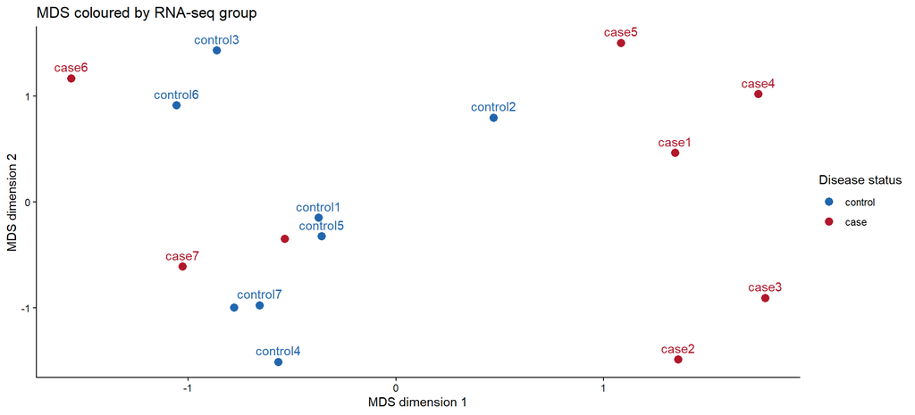

```r
dge_mds <- dge

dge_mds <- normLibSizes(dge_mds, method = "TMM")
keep <- filterByExpr(dge_mds, group = dge_mds$samples$group)
dge_mds <- dge_mds[keep, , keep.lib.sizes = FALSE]
dge_mds$samples$group <- factor(
  dge_mds$samples$group,
  levels = c("control", "case")
)

mds <- plotMDS(dge_mds, plot = FALSE)
mds_data <- dge_mds$samples %>%
  rownames_to_column("sample") %>%
  transmute(
    sample,
    donorid,
    group,
    MDS1 = mds$x,
    MDS2 = mds$y
  ) %>%
  left_join(rna_prs %>% select(donorid, PRS), by = "donorid")

p1 <- ggplot(mds_data, aes(MDS1, MDS2, colour = group, label = sample)) +
  geom_point(size = 3) +
  geom_text(vjust = -0.7, show.legend = FALSE, check_overlap = TRUE) +
  scale_colour_manual(values = c(control = "#2166AC", case = "#B2182B")) +
  theme_classic() +
  labs(
    title = "MDS coloured by RNA-seq group",
    x = "MDS dimension 1",
    y = "MDS dimension 2",
    colour = "Disease status"
  )

p2 <- ggplot(mds_data, aes(MDS1, MDS2, colour = PRS, label = sample)) +
  geom_point(size = 3) +
  geom_text(vjust = -0.7, show.legend = FALSE, check_overlap = TRUE) +
  scale_colour_viridis_c() +
  theme_classic() +
  labs(
    title = "MDS coloured by PRS",
    x = "MDS dimension 1",
    y = "MDS dimension 2",
    colour = "PRS"
  )

# Print the two panels separately so no additional plotting package is required.
print(p1)
```

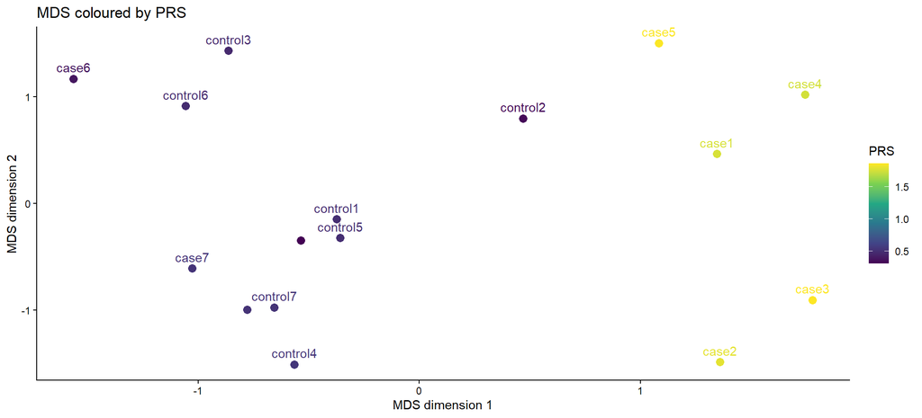

```r
print(p2)
```

The PRS colouring broadly follows the disease-status pattern: controls occupy the low-PRS range, whereas most case samples have higher PRS values. This indicates that genetic risk captured by these 15 loci is associated with the case-control distinction in this dataset, in addition to the transcriptional differences shown by the MDS plot. Nevertheless, PRS does not perfectly separate the samples and should not be treated as a diagnostic classifier.

Age, exercise status and gait-treatment assignment cannot be used as reliable case-control discriminators for the RNA-seq samples. Only eight RNA-seq donors have corresponding records in the gait dataset, and these overlapping donors are all cases. Therefore, there are no matched RNA-seq controls with which to compare those variables.

```r
gait_overlap <- gait_data %>%
  select(donorid, age, exercise, treatment) %>%
  inner_join(sample_info %>% select(donorid, group), by = "donorid")

gait_overlap %>%
  count(group, name = "RNA-seq donors with gait metadata") %>%
  knitr::kable()
```

| group | RNA-seq donors with gait metadata |
| --- | --- |
| case | 8 |

# Question 3

## Are any of the gene targets of hit compounds from the drug screen differentially expressed in RNA-seq? Which GO terms are they associated with and what might this tell you about the pathology of PD?

For question three, we can carry on from the compounds identified in the drug-screening analysis. Using the one-sided Welch tests with correction across all 192 compounds, the three hits were cmpd_7933, cmpd_4952 and cmpd_7429. These increased mean luminescence by approximately 39.9%, 42.0% and 35.9%, respectively, compared with their inactive controls. This follows the main analysis in our drug-screening report; the Wilcoxon sensitivity check did not retain significance after correction, so we should treat these as candidate hits for further investigation. To see whether their targets are also differentially expressed, we first need to find the genes that these compounds act on.

Looking at compound_dict, these compounds target APBA3, RIT2 and LARGE1, respectively, and all three are agonists. The target_enzyme column contains the Entrez gene IDs, which means we can use it to connect the compounds to the RNA-seq results.

Before joining these together, we need the differential expression results for cases compared with controls. We can follow the steps from Workshop 7, using normLibSizes() for TMM normalisation and filterByExpr() to remove genes with low expression. Here we keep the same order as our RNA-seq report, which retained 9,890 genes for the comparison.

`clb library(edgeR) library(limma) # Start from the supplied counts and follow the RNA-seq report. load("../data/rnaseq.Rda") dge <- normLibSizes(dge, method = "TMM") keep <- filterByExpr(dge, group = dge$samples$group) dge_filtered <- dge[keep, , keep.lib.sizes = FALSE] dge_filtered$samples$group <- factor( dge_filtered$samples$group, levels = c("control", "case") )}`

Now we can set up the design matrix based on the group column in dge_filtered$samples. Following the workshop, we use ~ 0 + group and then make a contrast for case minus control. This means a positive logFC shows higher expression in cases, while a negative logFC shows lower expression in cases.

`clb design <- model.matrix(~ 0 + group, data = dge_filtered$samples) colnames(design) <- levels(dge_filtered$samples$group) design contrast_matrix <- makeContrasts( case_vs_control = case - control, levels = design ) contrast_matrix}`

Since RNA-seq counts do not have the same spread at every expression level, we use voom() before fitting the linear model. We can then use lmFit(), contrasts.fit() and eBayes(), as in the workshop, to compare cases with controls. Finally, topTable() gives us the results for all tested genes, including their adjusted p-values.

The genes column in results contains the Entrez IDs. We can rename this column to target_enzyme so that it matches compound_dict, and use left_join() to add the RNA-seq results to our three hit compounds. The adjusted p-values were calculated across all tested genes, before selecting these three targets.

Now that we have identified the differentially expressed targets, we can use the gene_ontology dataframe to see which biological functions they are associated with. This dataframe uses entrezgene_id for its gene IDs, so we need to match target_enzyme to this column when joining.

However, lower gene expression does not automatically mean lower protein activity, and the drug screen used technical replicates from one healthy donor. We would therefore need further experiments to check whether these compounds act through the proposed targets and whether the same effect occurs in neurons from PD patients. These GO results show the annotations of our three targets; they do not test whether synaptic transmission is statistically enriched.

The RNA-seq steps follow [Workshop 7](https://wehi-education.github.io/BIOL90042_R_Course/workshop_7.html), and the experimental context follows [Tutorial 9](https://wehi-education.github.io/BIOL90042_R_Course/tutorial_9.html) of the WEHI course ebook.

# Question 4

## Is there any relationship between the PRS and gait of patients in the clinical trial?

To answer this question, we need information from two different arms of the study: the polygenic risk score (PRS) from the population genetics data (`prs.Rda`), and the gait data from the clinical trial (`gait.Rda`). Participants are identified by a unique `donorid`, so we can use this column to connect the two datasets. Only participants who appear in both datasets can be used.

## Setup

`clb # Load the tidyverse packages library(tidyverse) # Load the population genetics data and the clinical trial data # (both files sit in the same folder as this document) load("prs.Rda") load("gait.Rda")}`

## Step 1: Calculate the PRS for each participant

We calculate the PRS in the same way as in the population genetics section: reshape the genotypes into long format, join the GWAS effect sizes (beta) for each locus, multiply dosage by beta, and add up the 15 locus scores for each donor.

`clb # Reshape the genotypes so that each row is one donor at one locus genotypes_long <- ca_co_genotypes %>% pivot_longer( cols = -c(donorid, status), names_to = "locus", values_to = "dosage" ) # Add the GWAS effect size (beta) for each locus, and calculate the score for each locus prs_data <- genotypes_long %>% left_join(gwas_top_hits, by = "locus") %>% mutate( locus_score = dosage * beta # dosage x beta for each locus ) # Add the 15 locus scores together to get one PRS per donor participant_prs <- prs_data %>% summarise( PRS = sum(locus_score), .by = c(donorid, status) ) head(participant_prs)}`

## Step 2: Calculate the gait score for each participant

We calculate the gait score in the same way as in the clinical trial section: the standard deviation of each participant’s orientation over the 700 seconds. A larger gait score means a less smooth gait and poorer balance.

`clb # Reshape the gait data so that each row is one donor at one second gait_long <- gait_data %>% pivot_longer( cols = ends_with("_secs"), names_to = "time", values_to = "orientation" ) # Calculate the gait score (standard deviation of orientation) for each participant participant_gait <- gait_long %>% summarise( gait_score = sd(orientation), .by = c(donorid, treatment, age, exercise) ) head(participant_gait)}`

## Step 3: Join the two datasets using donorid

Before joining, we check how many of the 16 clinical trial participants also appear in the PRS data.

`clb # Which clinical trial participants are missing from the PRS data? (should be none if all 16 overlap) participant_gait %>% anti_join(participant_prs, by = "donorid")}`

All 16 clinical trial participants were also present in the population genetics dataset, so all 16 could be used in this analysis. All 16 were classified as cases, which is consistent with the clinical trial only including patients with PD.

## Step 4: Look at the relationship

We start with a scatterplot of PRS against gait score. We colour the points by treatment, because treatment was found to be related to gait in the clinical trial section.

**Description of the plot:**

## Step 5: Test the relationship

We use a Pearson correlation to test whether there is a linear relationship between PRS and gait score. This assumes a roughly linear relationship (which we checked in the scatterplot) and approximately normal variables, so we check normality of both variables and also run a Spearman correlation, which is rank-based and does not assume normality.

**Interpretation:**

## Step 6: Take treatment, age and exercise into account

In the clinical trial section, treatment, age and exercise were all related to gait. If the PRS is related to any of these, they could hide or create a relationship with gait. We first check that PRS is similar across treatment and exercise groups, and then fit a model that includes PRS together with these variables.

Since this is a linear model, we check its assumptions using the residuals.

**Interpretation & Final conclusion:**

**Limitations:**

- The sample is small (at most 16 participants), so the analysis has little power to detect a relationship, and the estimates are imprecise.
- The PRS values of these 16 participants form two separate clusters, with none in the middle, so we cannot tell how gait changes across intermediate PRS values.
- The PRS was built from 15 loci that were chosen because they are associated with PD risk. They were not chosen to predict gait severity, so the score may not be expected to capture motor symptoms.
- This analysis shows an association (or the lack of one) in this dataset, and does not show that genetic risk causes differences in gait.

# Question 5

## Reproducibility note

This document uses only R code and the supplied `.Rda` files. The RNA-seq MDS plot uses `edgeR::plotMDS()`, and all PRS summaries are recalculated from the genotype dosage and GWAS beta values during rendering.